# Forecasting of financial instruments using VECM and ARIMA

## Box Jenkins Procedure for y3

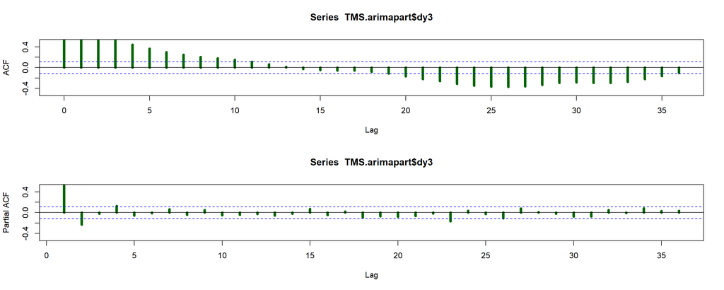

```r
par(mfrow = c(2, 1))
acf(TMS.arimapart$dy3,
    lag.max = 36, # max lag for ACF
    ylim = c(-0.5, 0.5),   # limits for the y axis - we give c(min, max)
    lwd = 5,               # line width
    col = "dark green",
    na.action = na.pass)   # do not stop if there are missing values in the data
pacf(TMS.arimapart$dy3,
     lag.max = 36,
     ylim = c(-0.5, 0.5),   # limits for the y axis - we give c(min, max)
     lwd = 5, col = "dark green",
     na.action = na.pass)
```

For y3, ACF values are significant till 10th lag and PACF values are significant till 2.

## Box Jenkins procedure for y10

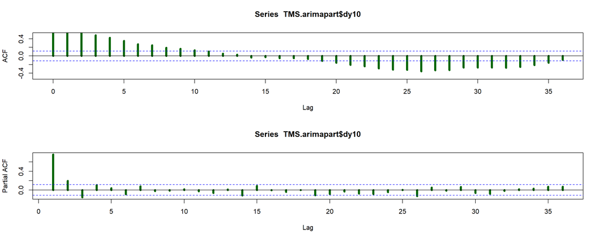

```r
par(mfrow = c(2, 1))
acf(TMS.arimapart$dy10,
    lag.max = 36, # max lag for ACF
    ylim = c(-0.5, 0.5),   # limits for the y axis - we give c(min, max)
    lwd = 5,               # line width
    col = "dark green",
    na.action = na.pass)   # do not stop if there are missing values in the data
pacf(TMS.arimapart$dy10,
     lag.max = 36,
     lwd = 5, col = "dark green",
     na.action = na.pass)
```

```r
par(mfrow = c(1, 1))
```

For y10, ACF values till 10th lag and PACF values till 3rd lag are significant.

## Checking models1 for y3

```r
arima111 <- Arima(TMS.arimapart$y3,  # variable
                  order = c(1, 1, 1)  # (p,d,q) parameters
)
arima111
```

```
Series: TMS.arimapart$y3
ARIMA(1,1,1)

Coefficients:
         ar1     ma1
      0.8232  0.2170
s.e.  0.0356  0.0558

sigma^2 = 1.059:  log likelihood = -432.55
AIC=871.09   AICc=871.17   BIC=882.19
```

```r
coeftest(arima111) #shows whether coefficenta are signifant or not
```

```
z test of coefficients:

    Estimate Std. Error z value   Pr(>|z|)
ar1 0.823240   0.035604 23.1224  < 2.2e-16 ***
ma1 0.217016   0.055754  3.8924 0.00009926 ***
---
Signif. codes:  0 '***' 0.001 '**' 0.01 '*' 0.05 '.' 0.1 ' ' 1
```

```r
summary(arima111)
```

```
Series: TMS.arimapart$y3
ARIMA(1,1,1)

Coefficients:
         ar1     ma1
      0.8232  0.2170
s.e.  0.0356  0.0558

sigma^2 = 1.059:  log likelihood = -432.55
AIC=871.09   AICc=871.17   BIC=882.19

Training set error measures:
                     ME     RMSE       MAE        MPE      MAPE     MASE
Training set 0.05390838 1.023838 0.8072486 0.02915556 0.3497714 0.457447
                   ACF1
Training set 0.02136456
```

```r
arima111_2 <- Arima(TMS.arimapart$y3,  # variable
                    order = c(1, 1, 1),  # (p,d,q) parameters
                    include.constant = TRUE)  # including a constant
arima111_2
```

```
Series: TMS.arimapart$y3
ARIMA(1,1,1) with drift

Coefficients:
         ar1     ma1   drift
      0.8179  0.2188  0.3510
s.e.  0.0362  0.0558  0.3903

sigma^2 = 1.06:  log likelihood = -432.15
AIC=872.31   AICc=872.44   BIC=887.11
```

```r
coeftest(arima111_2)
```

```
z test of coefficients:

      Estimate Std. Error z value   Pr(>|z|)
ar1   0.817850   0.036232 22.5728  < 2.2e-16 ***
ma1   0.218839   0.055793  3.9224 0.00008768 ***
drift 0.351044   0.390322  0.8994     0.3685
---
Signif. codes:  0 '***' 0.001 '**' 0.01 '*' 0.05 '.' 0.1 ' ' 1
```

```r
#drift is not significant we ignore it.
```

## Checking models2 for y3

```r
arima112 <- Arima(TMS.arimapart$y3, # variable
                   order = c(1,1,2 ))
arima112
```

```
Series: TMS.arimapart$y3
ARIMA(1,1,2)

Coefficients:
         ar1     ma1     ma2
      0.7421  0.3516  0.1970
s.e.  0.0568  0.0832  0.0766

sigma^2 = 1.04:  log likelihood = -429.41
AIC=866.82   AICc=866.96   BIC=881.62
```

```r
coeftest(arima112)
```

```
z test of coefficients:

    Estimate Std. Error z value   Pr(>|z|)
ar1 0.742066   0.056838 13.0557  < 2.2e-16 ***
ma1 0.351641   0.083159  4.2285 0.00002352 ***
ma2 0.197019   0.076590  2.5724     0.0101 *
---
Signif. codes:  0 '***' 0.001 '**' 0.01 '*' 0.05 '.' 0.1 ' ' 1
```

```r
arima112_2 <- Arima(TMS.arimapart$y3,  # variable
                    order = c(1, 1, 2),  # (p,d,q) parameters
                    include.constant = TRUE)  # including a constant
arima112_2
```

```
Series: TMS.arimapart$y3
ARIMA(1,1,2) with drift

Coefficients:
         ar1     ma1     ma2   drift
      0.7324  0.3579  0.2019  0.3541
s.e.  0.0583  0.0837  0.0767  0.3379

sigma^2 = 1.04:  log likelihood = -428.88
AIC=867.76   AICc=867.96   BIC=886.26
```

```r
coeftest(arima112_2)
```

```
z test of coefficients:

      Estimate Std. Error z value   Pr(>|z|)
ar1   0.732442   0.058279 12.5678  < 2.2e-16 ***
ma1   0.357874   0.083705  4.2754 0.00001908 ***
ma2   0.201922   0.076706  2.6324   0.008478 **
drift 0.354075   0.337886  1.0479   0.294678
---
Signif. codes:  0 '***' 0.001 '**' 0.01 '*' 0.05 '.' 0.1 ' ' 1
```

```r
#drift is not significant we ignore it.
```

It has lower information criteria and all of coefficents are significant. At least, it is better than ARIMA(1,1,1).

## Checking models3 for y3

```r
arima211 <- Arima(TMS.arimapart$y3,  # variable
                  order = c(2, 1, 1)  # (p,d,q) parameters
)
arima211
```

```
Series: TMS.arimapart$y3
ARIMA(2,1,1)

Coefficients:
         ar1      ar2     ma1
      1.1163  -0.2679  -0.047
s.e.  0.1744   0.1540   0.176

sigma^2 = 1.053:  log likelihood = -431.3
AIC=870.6   AICc=870.73   BIC=885.4
```

```r
coeftest(arima211)
```

```
z test of coefficients:

     Estimate Std. Error z value        Pr(>|z|)
ar1  1.116331   0.174355  6.4026 0.0000000001527 ***
ar2 -0.267948   0.153973 -1.7402         0.08182 .
ma1 -0.047011   0.176040 -0.2670         0.78943
---
Signif. codes:  0 '***' 0.001 '**' 0.01 '*' 0.05 '.' 0.1 ' ' 1
```

```r
arima211_2 <- Arima(TMS.arimapart$y3,  # variable
                    order = c(2, 1, 1),  # (p,d,q) parameters
                    include.constant = TRUE)  # including a constant
arima211_2
```

```
Series: TMS.arimapart$y3
ARIMA(2,1,1) with drift

Coefficients:
         ar1      ar2      ma1   drift
      1.1207  -0.2762  -0.0542  0.3523
s.e.  0.1738   0.1529   0.1760  0.3545

sigma^2 = 1.054:  log likelihood = -430.82
AIC=871.64   AICc=871.85   BIC=890.15
```

```r
coeftest(arima211_2)
```

```
z test of coefficients:

       Estimate Std. Error z value        Pr(>|z|)
ar1    1.120688   0.173833  6.4469 0.0000000001142 ***
ar2   -0.276165   0.152852 -1.8067          0.0708 .
ma1   -0.054192   0.176020 -0.3079          0.7582
drift  0.352255   0.354486  0.9937          0.3204
---
Signif. codes:  0 '***' 0.001 '**' 0.01 '*' 0.05 '.' 0.1 ' ' 1
```

```r
# drift is not significant and we ignore
```

Its information criteria is higher and some of coefficents are not significant. Still Arima(1,1,2) is best choice.

## Checking models4 for y3

```r
arima113 <- Arima(TMS.arimapart$y3,  # variable
                  order = c(1, 1, 3)  # (p,d,q) parameters
)
arima113
```

```
Series: TMS.arimapart$y3
ARIMA(1,1,3)

Coefficients:
         ar1     ma1     ma2      ma3
      0.8287  0.2506  0.0846  -0.1528
s.e.  0.0573  0.0845  0.0860   0.0800

sigma^2 = 1.031:  log likelihood = -427.66
AIC=865.32   AICc=865.53   BIC=883.82
```

```r
coeftest(arima113)
```

```
z test of coefficients:

     Estimate Std. Error z value  Pr(>|z|)
ar1  0.828733   0.057339 14.4533 < 2.2e-16 ***
ma1  0.250646   0.084506  2.9660  0.003017 **
ma2  0.084584   0.085995  0.9836  0.325316
ma3 -0.152808   0.080038 -1.9092  0.056236 .
---
Signif. codes:  0 '***' 0.001 '**' 0.01 '*' 0.05 '.' 0.1 ' ' 1
```

```r
arima113_2 <- Arima(TMS.arimapart$y3,  # variable
                    order = c(1, 1, 3),  # (p,d,q) parameters
                    include.constant = TRUE)  # including a constant
arima113_2
```

```
Series: TMS.arimapart$y3
ARIMA(1,1,3) with drift

Coefficients:
         ar1    ma1     ma2      ma3   drift
      0.8198  0.257  0.0905  -0.1484  0.3524
s.e.  0.0597  0.086  0.0872   0.0806  0.3820

sigma^2 = 1.032:  log likelihood = -427.25
AIC=866.5   AICc=866.79   BIC=888.71
```

```r
coeftest(arima113_2)
```

```
z test of coefficients:

       Estimate Std. Error z value  Pr(>|z|)
ar1    0.819844   0.059687 13.7357 < 2.2e-16 ***
ma1    0.256971   0.086001  2.9880  0.002808 **
ma2    0.090468   0.087164  1.0379  0.299314
ma3   -0.148404   0.080613 -1.8409  0.065631 .
drift  0.352428   0.381977  0.9226  0.356194
---
Signif. codes:  0 '***' 0.001 '**' 0.01 '*' 0.05 '.' 0.1 ' ' 1
```

```r
# drift is not significant and we ignore it
```

Here Information criteria is lower than our previous last choice but some of coefficents are non-significant. For goodness-of-fit, I choose this model.

```r
y10_arima212 <- Arima(TMS.arimapart$y3,  # variable
                  order = c(2, 1, 2)  # (p,d,q) parameters
)
y10_arima212
```

```
Series: TMS.arimapart$y3
ARIMA(2,1,2)

Coefficients:
         ar1     ar2     ma1     ma2
      0.3676  0.3115  0.7182  0.2992
s.e.  0.1843  0.1577  0.1789  0.0767

sigma^2 = 1.035:  log likelihood = -428.2
AIC=866.41   AICc=866.61   BIC=884.91
```

```r
coeftest(y10_arima212)
```

```
z test of coefficients:

    Estimate Std. Error z value   Pr(>|z|)
ar1 0.367610   0.184335  1.9942    0.04613 *
ar2 0.311501   0.157742  1.9748    0.04830 *
ma1 0.718177   0.178935  4.0136 0.00005979 ***
ma2 0.299187   0.076665  3.9025 0.00009520 ***
---
Signif. codes:  0 '***' 0.001 '**' 0.01 '*' 0.05 '.' 0.1 ' ' 1
```

```r
y10_arima212_2 <- Arima(TMS.arimapart$y3,  # variable
                    order = c(2, 1, 2),  # (p,d,q) parameters
                    include.constant = TRUE)  # including a constant
y10_arima212_2
```

```
Series: TMS.arimapart$y3
ARIMA(2,1,2) with drift

Coefficients:
         ar1     ar2     ma1     ma2   drift
      0.3655  0.3040  0.7167  0.3015  0.3530
s.e.  0.1854  0.1578  0.1800  0.0769  0.3522

sigma^2 = 1.035:  log likelihood = -427.72
AIC=867.43   AICc=867.72   BIC=889.64
```

```r
coeftest(y10_arima212_2)
```

```
z test of coefficients:

      Estimate Std. Error z value   Pr(>|z|)
ar1   0.365550   0.185402  1.9717    0.04865 *
ar2   0.304002   0.157799  1.9265    0.05404 .
ma1   0.716699   0.179952  3.9827 0.00006813 ***
ma2   0.301517   0.076913  3.9203 0.00008846 ***
drift 0.352976   0.352158  1.0023    0.31619
---
Signif. codes:  0 '***' 0.001 '**' 0.01 '*' 0.05 '.' 0.1 ' ' 1
```

```r
 #We ignore drift
```

Our AIC information criteria is 866 and all coefficents are significant..

```r
y10_arima313 <- Arima(TMS.arimapart$y3,  # variable
                      order = c(3, 1, 3)  # (p,d,q) parameters
)
y10_arima313
```

```
Series: TMS.arimapart$y3
ARIMA(3,1,3)

Coefficients:
          ar1     ar2     ar3     ma1     ma2     ma3
      -0.7283  0.3599  0.7221  1.8632  1.4738  0.3285
s.e.   0.0517  0.0603  0.0494  0.0691  0.0999  0.0667

sigma^2 = 1.016:  log likelihood = -425
AIC=863.99   AICc=864.38   BIC=889.9
```

```r
coeftest(y10_arima313)
```

```
z test of coefficients:

     Estimate Std. Error  z value       Pr(>|z|)
ar1 -0.728332   0.051680 -14.0930      < 2.2e-16 ***
ar2  0.359917   0.060277   5.9711 0.000000002357 ***
ar3  0.722057   0.049385  14.6209      < 2.2e-16 ***
ma1  1.863178   0.069140  26.9480      < 2.2e-16 ***
ma2  1.473794   0.099926  14.7489      < 2.2e-16 ***
ma3  0.328478   0.066700   4.9247 0.000000845005 ***
---
Signif. codes:  0 '***' 0.001 '**' 0.01 '*' 0.05 '.' 0.1 ' ' 1
```

```r
summary(y10_arima313)
```

```
Series: TMS.arimapart$y3
ARIMA(3,1,3)

Coefficients:
          ar1     ar2     ar3     ma1     ma2     ma3
      -0.7283  0.3599  0.7221  1.8632  1.4738  0.3285
s.e.   0.0517  0.0603  0.0494  0.0691  0.0999  0.0667

sigma^2 = 1.016:  log likelihood = -425
AIC=863.99   AICc=864.38   BIC=889.9

Training set error measures:
                     ME      RMSE       MAE        MPE      MAPE      MASE
Training set 0.05203032 0.9961157 0.7770729 0.02783753 0.3367881 0.4403472
                   ACF1
Training set -0.0366561
```

```r
#It is better than previous estimation since all coefficent are significant and It has lower information criteria.
```

It is better than previous estimation since all coefficents are significant and It has lower information criteria.

```r
y10_arima314 <- Arima(TMS.arimapart$y3,  # variable
                      order = c(3, 1, 4)  # (p,d,q) parameters
)
y10_arima314
```

```
Series: TMS.arimapart$y3
ARIMA(3,1,4)

Coefficients:
          ar1     ar2     ar3     ma1     ma2     ma3      ma4
      -0.4776  0.6073  0.3532  1.5626  0.8918  0.1271  -0.0909
s.e.   0.2941  0.2483  0.2741  0.2973  0.4909  0.2589   0.1165

sigma^2 = 1.034:  log likelihood = -426.54
AIC=869.09   AICc=869.58   BIC=898.69
```

```r
coeftest(y10_arima314)
```

```
z test of coefficients:

     Estimate Std. Error z value     Pr(>|z|)
ar1 -0.477621   0.294107 -1.6240      0.10438
ar2  0.607319   0.248328  2.4456      0.01446 *
ar3  0.353157   0.274096  1.2884      0.19759
ma1  1.562643   0.297296  5.2562 0.0000001471 ***
ma2  0.891780   0.490875  1.8167      0.06926 .
ma3  0.127139   0.258862  0.4911      0.62332
ma4 -0.090938   0.116510 -0.7805      0.43509
---
Signif. codes:  0 '***' 0.001 '**' 0.01 '*' 0.05 '.' 0.1 ' ' 1
```

```r
summary(y10_arima314)
```

```
Series: TMS.arimapart$y3
ARIMA(3,1,4)

Coefficients:
          ar1     ar2     ar3     ma1     ma2     ma3      ma4
      -0.4776  0.6073  0.3532  1.5626  0.8918  0.1271  -0.0909
s.e.   0.2941  0.2483  0.2741  0.2973  0.4909  0.2589   0.1165

sigma^2 = 1.034:  log likelihood = -426.54
AIC=869.09   AICc=869.58   BIC=898.69

Training set error measures:
                     ME     RMSE       MAE        MPE      MAPE      MASE
Training set 0.05503733 1.003119 0.7849284 0.02929993 0.3400635 0.4447987
                     ACF1
Training set -0.001214331
```

## et’s use this beautiful code taking into account of only information criteria.

```r
arima.best.AIC <-
  auto.arima(TMS.arimapart$y3,
             d = 1,             # parameter d of ARIMA model
             max.p = 6,         # Maximum value of p
             max.q = 6,         # Maximum value of q
             max.order = 12,    # maximum p+q
             start.p = 1,       # Starting value of p in stepwise procedure
             start.q = 1,       # Starting value of q in stepwise procedure
             ic = "aic",        # Information criterion to be used in model selection.
             stepwise = FALSE,  # if FALSE considers all models
             allowdrift = TRUE, # include a constant
             trace = TRUE)      # show summary of all models considered
```

```
 Fitting models using approximations to speed things up...

 ARIMA(0,1,0)                    : 1308.749
 ARIMA(0,1,0) with drift         : 1301.618
 ARIMA(0,1,1)                    : 1068.415
 ARIMA(0,1,1) with drift         : 1063.986
 ARIMA(0,1,2)                    : 933.5096
 ARIMA(0,1,2) with drift         : 931.3783
 ARIMA(0,1,3)                    : 901.523
 ARIMA(0,1,3) with drift         : 900.5292
 ARIMA(0,1,4)                    : 886.7096
 ARIMA(0,1,4) with drift         : 886.4316
 ARIMA(0,1,5)                    : 875.9129
 ARIMA(0,1,5) with drift         : 876.3092
 ARIMA(0,1,6)                    : 876.0923
 ARIMA(0,1,6) with drift         : 876.6186
 ARIMA(1,1,0)                    : 880.6256
 ARIMA(1,1,0) with drift         : 882.0434
 ARIMA(1,1,1)                    : 869.1987
 ARIMA(1,1,1) with drift         : 870.3328
 ARIMA(1,1,2)                    : 864.9552
 ARIMA(1,1,2) with drift         : 865.6984
 ARIMA(1,1,3)                    : 863.4044
 ARIMA(1,1,3) with drift         : 864.5231
 ARIMA(1,1,4)                    : 865.3663
 ARIMA(1,1,4) with drift         : 866.4425
 ARIMA(1,1,5)                    : 867.3638
 ARIMA(1,1,5) with drift         : 868.4157
 ARIMA(1,1,6)                    : 868.8967
 ARIMA(1,1,6) with drift         : 870.0535
 ARIMA(2,1,0)                    : 863.445
 ARIMA(2,1,0) with drift         : 864.6766
 ARIMA(2,1,1)                    : 865.3857
 ARIMA(2,1,1) with drift         : 866.6055
 ARIMA(2,1,2)                    : 861.7934
 ARIMA(2,1,2) with drift         : 862.7851
 ARIMA(2,1,3)                    : 861.6243
 ARIMA(2,1,3) with drift         : 862.9831
 ARIMA(2,1,4)                    : 863.3504
 ARIMA(2,1,4) with drift         : Inf
```

[output cut: 52 more lines]

```
 ARIMA(6,1,3)                    : Inf
 ARIMA(6,1,3) with drift         : Inf
 ARIMA(6,1,4)                    : Inf
 ARIMA(6,1,4) with drift         : Inf
 ARIMA(6,1,5)                    : Inf
 ARIMA(6,1,5) with drift         : Inf
 ARIMA(6,1,6)                    : Inf
 ARIMA(6,1,6) with drift         : Inf

 Now re-fitting the best model(s) without approximations...




 Best model: ARIMA(2,1,3)
```

```r
coeftest(arima.best.AIC)
```

```
z test of coefficients:

    Estimate Std. Error z value Pr(>|z|)
ar1  0.72485    0.45676  1.5869   0.1125
ar2  0.07962    0.34436  0.2312   0.8171
ma1  0.35309    0.45497  0.7761   0.4377
ma2  0.11944    0.18095  0.6601   0.5092
ma3 -0.13608    0.11440 -1.1895   0.2343
```

It has lowest information criteria but coefficents are not significant.

```r
y10_arima.best.AIC <- auto.arima(TMS.arimapart$y10,
                                 d = 1,             # parameter d of ARIMA model
                                 max.p = 6,         # Maximum value of p
                                 max.q = 6,         # Maximum value of q
                                 max.order = 12,    # maximum p+q
                                 start.p = 1,       # Starting value of p in stepwise procedure
                                 start.q = 1,       # Starting value of q in stepwise procedure
                                 ic = "aic",        # Information criterion to be used in model selection.
                                 stepwise = FALSE,  # if FALSE considers all models
                                 allowdrift = TRUE, # include a constant
                                 trace = TRUE)      # show summary of all models considered
```

```
 Fitting models using approximations to speed things up...

 ARIMA(0,1,0)                    : 919.8482
 ARIMA(0,1,0) with drift         : 913.5013
 ARIMA(0,1,1)                    : 789.8636
 ARIMA(0,1,1) with drift         : 786.3076
 ARIMA(0,1,2)                    : 681.6209
 ARIMA(0,1,2) with drift         : 679.8767
 ARIMA(0,1,3)                    : 671.2678
 ARIMA(0,1,3) with drift         : 670.4239
 ARIMA(0,1,4)                    : 656.767
 ARIMA(0,1,4) with drift         : 656.5026
 ARIMA(0,1,5)                    : 650.1432
 ARIMA(0,1,5) with drift         : 650.2832
 ARIMA(0,1,6)                    : 650.3876
 ARIMA(0,1,6) with drift         : 650.6718
 ARIMA(1,1,0)                    : 659.6971
 ARIMA(1,1,0) with drift         : 660.6748
 ARIMA(1,1,1)                    : 653.0469
 ARIMA(1,1,1) with drift         : 654.3991
 ARIMA(1,1,2)                    : 647.6062
 ARIMA(1,1,2) with drift         : 648.5343
 ARIMA(1,1,3)                    : 640.7574
 ARIMA(1,1,3) with drift         : 642.1934
 ARIMA(1,1,4)                    : 640.6352
 ARIMA(1,1,4) with drift         : 641.8894
 ARIMA(1,1,5)                    : 642.4356
 ARIMA(1,1,5) with drift         : 643.7541
 ARIMA(1,1,6)                    : 644.2745
 ARIMA(1,1,6) with drift         : 645.6286
 ARIMA(2,1,0)                    : 648.6368
 ARIMA(2,1,0) with drift         : 650.1194
 ARIMA(2,1,1)                    : 643.3463
 ARIMA(2,1,1) with drift         : 644.7078
 ARIMA(2,1,2)                    : 642.3904
 ARIMA(2,1,2) with drift         : 643.5202
 ARIMA(2,1,3)                    : 640.711
 ARIMA(2,1,3) with drift         : 642.1819
 ARIMA(2,1,4)                    : 641.8232
 ARIMA(2,1,4) with drift         : 643.3761
```

[output cut: 152 more lines]

```
 ARIMA(6,1,2) with drift         : 642.2265
 ARIMA(6,1,3)                    : Inf
 ARIMA(6,1,3) with drift         : Inf
 ARIMA(6,1,4)                    : Inf
 ARIMA(6,1,4) with drift         : Inf
 ARIMA(6,1,5)                    : Inf
 ARIMA(6,1,5) with drift         : Inf
 ARIMA(6,1,6)                    : Inf
 ARIMA(6,1,6) with drift         : Inf





 Best model: ARIMA(3,1,2)
```

```r
coeftest(y10_arima.best.AIC)
```

```
z test of coefficients:

     Estimate Std. Error z value           Pr(>|z|)
ar1 -0.449081   0.105266 -4.2662 0.0000198867375112 ***
ar2  0.303120   0.100606  3.0129           0.002587 **
ar3  0.536404   0.089012  6.0262 0.0000000016789571 ***
ma1  1.144355   0.089870 12.7334          < 2.2e-16 ***
ma2  0.757863   0.101857  7.4405 0.0000000000001003 ***
---
Signif. codes:  0 '***' 0.001 '**' 0.01 '*' 0.05 '.' 0.1 ' ' 1
```

# Model Diagnostics for y3

## Plotting residuals

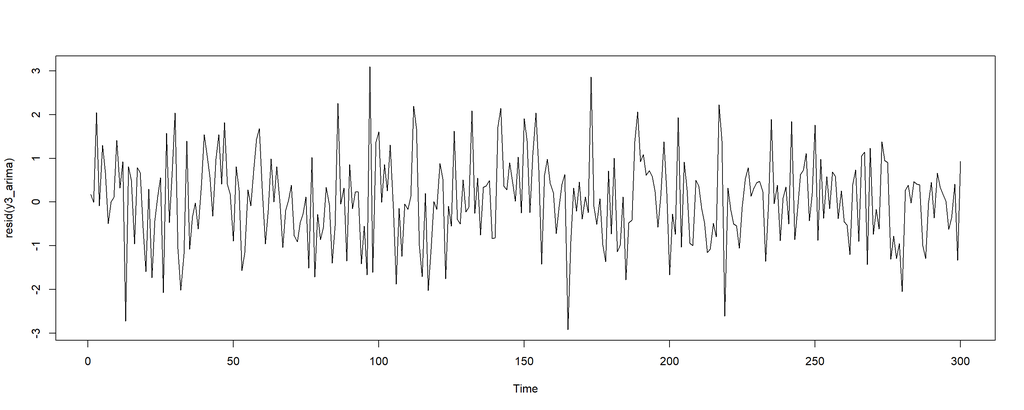

```r
y3_arima <- arima113
plot(resid(y3_arima))
```

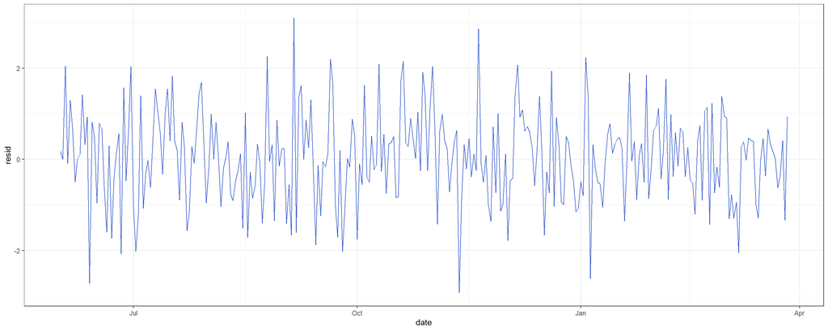

```r
tibble(
  date = index(TMS.arimapart),
  resid = arima113 %>% resid() %>% as.numeric()
) %>%
  ggplot(aes(date, resid)) +
  geom_line(col = "royalblue3") +
  theme_bw()
```

Visually we can conclude that our residuals are whit noise.

## ACF and PACF plot of residuals

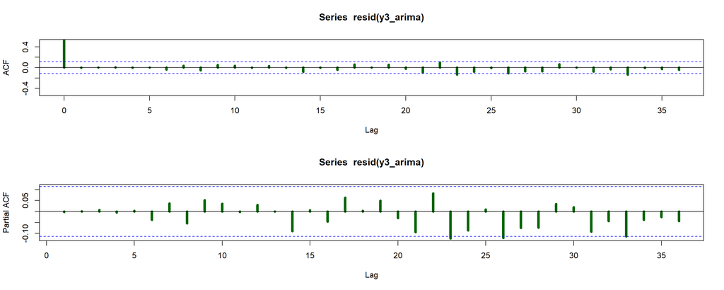

```r
par(mfrow = c(2, 1))
acf(resid(y3_arima),
    lag.max = 36,
    ylim = c(-0.5, 0.5),
    lwd = 5, col = "dark green",
    na.action = na.pass)
pacf(resid(y3_arima),
     lag.max = 36,
     lwd = 5, col = "dark green",
     na.action = na.pass)
```

```r
par(mfrow = c(1, 1))
```

Visually till high lags, we cannot see autocorrelation, however it should be better to test statistically.

## Ljung box test for residuals

```r
Box.test(resid(y3_arima), type = "Ljung-Box", lag = 5)
```

```
    Box-Ljung test

data:  resid(y3_arima)
X-squared = 0.028645, df = 5, p-value = 1
```

```r
Box.test(resid(y3_arima), type = "Ljung-Box", lag = 10)
```

```
    Box-Ljung test

data:  resid(y3_arima)
X-squared = 3.0289, df = 10, p-value = 0.9807
```

```r
Box.test(resid(y3_arima), type = "Ljung-Box", lag = 15)
```

```
    Box-Ljung test

data:  resid(y3_arima)
X-squared = 5.5429, df = 15, p-value = 0.9864
```

P values are higher than significance level, so we cannot reject our residuals are not autocorrelated. Residuals are free from autocorrelation till lag=15, we can use it for forecasting.

## Model Diagnostics for y10(plotting residuals)

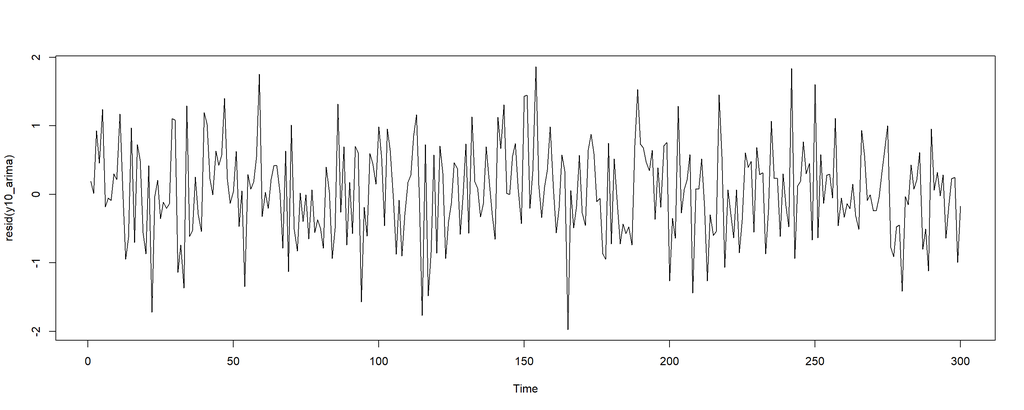

```r
y10_arima <- y10_arima.best.AIC
plot(resid(y10_arima))
```

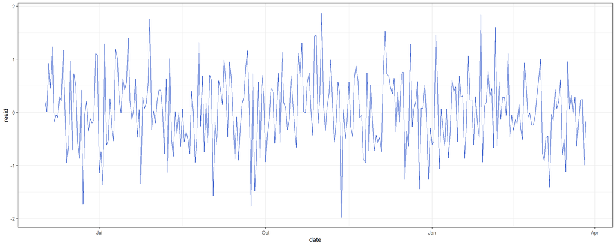

```r
tibble(
  date = index(TMS.arimapart),
  resid = y10_arima %>% resid() %>% as.numeric()
) %>%
  ggplot(aes(date, resid)) +
  geom_line(col = "royalblue3") +
  theme_bw()
```

## ACF and PACF plot of residuals

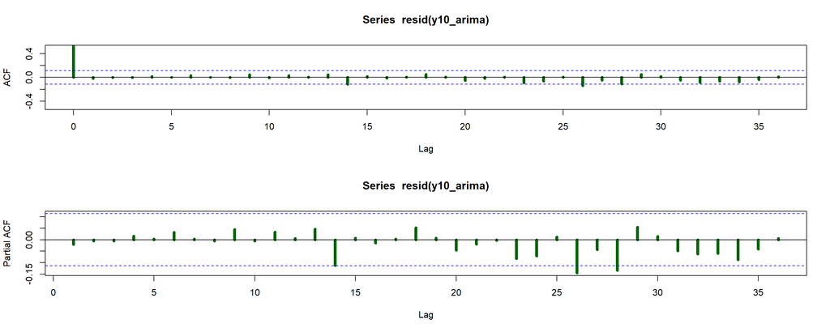

```r
par(mfrow = c(2, 1))
acf(resid(y10_arima),
    lag.max = 36,
    ylim = c(-0.5, 0.5),
    lwd = 5, col = "dark green",
    na.action = na.pass)
pacf(resid(y10_arima),
     lag.max = 36,
     lwd = 5, col = "dark green",
     na.action = na.pass)
```

```r
par(mfrow = c(1, 1))
```

Our residuals are white noise but still we need to test statistically.

## Ljung box test for residuals

```r
Box.test(resid(y10_arima), type = "Ljung-Box", lag = 5)
```

```
    Box-Ljung test

data:  resid(y10_arima)
X-squared = 0.21602, df = 5, p-value = 0.9989
```

```r
Box.test(resid(y10_arima), type = "Ljung-Box", lag = 10)
```

```
    Box-Ljung test

data:  resid(y10_arima)
X-squared = 1.1619, df = 10, p-value = 0.9997
```

```r
Box.test(resid(y10_arima), type = "Ljung-Box", lag = 15)
```

```
    Box-Ljung test

data:  resid(y10_arima)
X-squared = 6.363, df = 15, p-value = 0.973
```

Residuals of y10_arima are free from autocorrelation

## Forecasting for y3

```r
tail(TMS.arimapart, 20)
```

```
               y3    y10   dy3  dy10
2022-03-08 302.89 253.33 -3.87 -1.81
2022-03-09 300.11 251.60 -2.78 -1.73
2022-03-10 298.22 250.84 -1.89 -0.76
2022-03-11 297.11 250.14 -1.11 -0.70
2022-03-12 296.66 249.92 -0.45 -0.22
2022-03-13 296.83 250.31  0.17  0.39
2022-03-14 296.04 249.75 -0.79 -0.56
2022-03-15 293.82 249.04 -2.22 -0.71
2022-03-16 291.49 247.09 -2.33 -1.95
2022-03-17 290.05 246.74 -1.44 -0.35
2022-03-18 288.80 246.23 -1.25 -0.51
2022-03-19 288.38 246.42 -0.42  0.19
2022-03-20 288.44 246.38  0.06 -0.04
2022-03-21 288.86 246.68  0.42  0.30
2022-03-22 289.20 246.30  0.34 -0.38
2022-03-23 288.83 245.85 -0.37 -0.45
2022-03-24 287.98 245.64 -0.85 -0.21
2022-03-25 287.54 245.77 -0.44  0.13
2022-03-26 286.01 244.87 -1.53 -0.90
2022-03-27 285.43 244.08 -0.58 -0.79
```

```r
forecasts <- forecast(y3_arima, # model for prediction
                      h = 20) # how many periods outside the sample
forecasts
```

```
    Point Forecast    Lo 80    Hi 80    Lo 95    Hi 95
301       285.0073 283.7059 286.3087 283.0169 286.9976
302       284.9394 281.9366 287.9422 280.3470 289.5318
303       284.7407 279.7547 289.7267 277.1153 292.3662
304       284.5761 277.6291 291.5232 273.9515 295.2007
305       284.4397 275.5493 293.3301 270.8429 298.0365
306       284.3266 273.5240 295.1293 267.8055 300.8478
307       284.2329 271.5610 296.9049 264.8529 303.6130
308       284.1553 269.6646 298.6460 261.9937 306.3169
309       284.0909 267.8366 300.3453 259.2320 308.9498
310       284.0376 266.0767 301.9985 256.5688 311.5065
311       283.9934 264.3833 303.6035 254.0024 313.9844
312       283.9568 262.7541 305.1595 251.5301 316.3835
313       283.9264 261.1860 306.6668 249.1480 318.7049
314       283.9013 259.6759 308.1267 246.8518 320.9508
315       283.8804 258.2204 309.5405 244.6368 323.1240
316       283.8632 256.8163 310.9100 242.4985 325.2278
317       283.8488 255.4603 312.2374 240.4323 327.2654
318       283.8370 254.1493 313.5247 238.4336 329.2404
319       283.8271 252.8804 314.7738 236.4983 331.1560
320       283.8190 251.6510 315.9870 234.6223 333.0157
```

```r
str(forecasts)
```

```
List of 10
 $ method   : chr "ARIMA(1,1,3)"
 $ model    :List of 18
  ..$ coef     : Named num [1:4] 0.8287 0.2506 0.0846 -0.1528
  .. ..- attr(*, "names")= chr [1:4] "ar1" "ma1" "ma2" "ma3"
  ..$ sigma2   : num 1.03
  ..$ var.coef : num [1:4, 1:4] 0.00329 -0.00355 -0.00364 -0.00302 -0.00355 ...
  .. ..- attr(*, "dimnames")=List of 2
  .. .. ..$ : chr [1:4] "ar1" "ma1" "ma2" "ma3"
  .. .. ..$ : chr [1:4] "ar1" "ma1" "ma2" "ma3"
  ..$ mask     : logi [1:4] TRUE TRUE TRUE TRUE
  ..$ loglik   : num -428
  ..$ aic      : num 865
  ..$ arma     : int [1:7] 1 3 0 0 1 1 0
  ..$ residuals: Time-Series [1:300] from 1 to 300: 0.17357 -0.000321 2.04479 -0.088908 1.294769 ...
  ..$ call     : language Arima(y = TMS.arimapart$y3, order = c(1, 1, 3))
  ..$ series   : chr "TMS.arimapart$y3"
  ..$ code     : int 0
  ..$ n.cond   : int 0
  ..$ nobs     : int 299
  ..$ model    :List of 10
  .. ..$ phi  : num 0.829
  .. ..$ theta: num [1:3] 0.2506 0.0846 -0.1528
  .. ..$ Delta: num 1
  .. ..$ Z    : num [1:5] 1 0 0 0 1
  .. ..$ a    : num [1:5] -0.58 0.058 0.282 -0.142 286.01
  .. ..$ P    : num [1:5, 1:5] 0.00 0.00 0.00 0.00 -1.52e-17 ...
  .. ..$ T    : num [1:5, 1:5] 0.829 0 0 0 1 ...
  .. ..$ V    : num [1:5, 1:5] 1 0.2506 0.0846 -0.1528 0 ...
  .. ..$ h    : num 0
  .. ..$ Pn   : num [1:5, 1:5] 1.00 2.51e-01 8.46e-02 -1.53e-01 1.30e-17 ...
  ..$ aicc     : num 866
  ..$ bic      : num 884
  ..$ x        : Time-Series [1:300] from 1 to 300: 174 174 176 178 181 ...
  ..$ fitted   : Time-Series [1:300] from 1 to 300: 173 174 174 178 180 ...
  ..- attr(*, "class")= chr [1:3] "forecast_ARIMA" "ARIMA" "Arima"
 $ level    : num [1:2] 80 95
 $ mean     : Time-Series [1:20] from 301 to 320: 285 285 285 285 284 ...
 $ lower    : Time-Series [1:20, 1:2] from 301 to 320: 284 282 280 278 276 ...
  ..- attr(*, "dimnames")=List of 2
  .. ..$ : NULL
  .. ..$ : chr [1:2] "80%" "95%"
 $ upper    : Time-Series [1:20, 1:2] from 301 to 320: 286 288 290 292 293 ...
  ..- attr(*, "dimnames")=List of 2
  .. ..$ : NULL
  .. ..$ : chr [1:2] "80%" "95%"
 $ x        : Time-Series [1:300] from 1 to 300: 174 174 176 178 181 ...
 $ series   : chr "TMS.arimapart$y3"
 $ fitted   : Time-Series [1:300] from 1 to 300: 173 174 174 178 180 ...
 $ residuals: Time-Series [1:300] from 1 to 300: 0.17357 -0.000321 2.04479 -0.088908 1.294769 ...
 - attr(*, "class")= chr "forecast"
```

```r
forecasts$mean
```

```
Time Series:
Start = 301
End = 320
Frequency = 1
 [1] 285.0073 284.9394 284.7407 284.5761 284.4397 284.3266 284.2329 284.1553
 [9] 284.0909 284.0376 283.9934 283.9568 283.9264 283.9013 283.8804 283.8632
[17] 283.8488 283.8370 283.8271 283.8190
```

```r
class(forecasts$mean)
```

```
[1] "ts"
```

```r
as.numeric(forecasts$mean)
```

```
 [1] 285.0073 284.9394 284.7407 284.5761 284.4397 284.3266 284.2329 284.1553
 [9] 284.0909 284.0376 283.9934 283.9568 283.9264 283.9013 283.8804 283.8632
[17] 283.8488 283.8370 283.8271 283.8190
```

```r
forecasts$lower
```

```
Time Series:
Start = 301
End = 320
Frequency = 1
         80%      95%
301 283.7059 283.0169
302 281.9366 280.3470
303 279.7547 277.1153
304 277.6291 273.9515
305 275.5493 270.8429
306 273.5240 267.8055
307 271.5610 264.8529
308 269.6646 261.9937
309 267.8366 259.2320
310 266.0767 256.5688
311 264.3833 254.0024
312 262.7541 251.5301
313 261.1860 249.1480
314 259.6759 246.8518
315 258.2204 244.6368
316 256.8163 242.4985
317 255.4603 240.4323
318 254.1493 238.4336
319 252.8804 236.4983
320 251.6510 234.6223
```

```r
forecasts$upper
```

```
Time Series:
Start = 301
End = 320
Frequency = 1
         80%      95%
301 286.3087 286.9976
302 287.9422 289.5318
303 289.7267 292.3662
304 291.5232 295.2007
305 293.3301 298.0365
306 295.1293 300.8478
307 296.9049 303.6130
308 298.6460 306.3169
309 300.3453 308.9498
310 301.9985 311.5065
311 303.6035 313.9844
312 305.1595 316.3835
313 306.6668 318.7049
314 308.1267 320.9508
315 309.5405 323.1240
316 310.9100 325.2278
317 312.2374 327.2654
318 313.5247 329.2404
319 314.7738 331.1560
320 315.9870 333.0157
```

```r
forecasts_data <- data.frame(f_mean  = as.numeric(forecasts$mean),
                             f_lower = as.numeric(forecasts$lower[, 2]),
                             f_upper = as.numeric(forecasts$upper[, 2]))
forecasts_data
```

| f_mean | f_lower | f_upper |
| --- | --- | --- |
| 285.0073 | 283.0169 | 286.9976 |
| 284.9394 | 280.3470 | 289.5318 |
| 284.7407 | 277.1153 | 292.3662 |
| 284.5761 | 273.9515 | 295.2007 |
| 284.4397 | 270.8429 | 298.0365 |
| 284.3266 | 267.8055 | 300.8478 |
| 284.2329 | 264.8529 | 303.6130 |
| 284.1553 | 261.9937 | 306.3169 |
| 284.0909 | 259.2320 | 308.9498 |
| 284.0376 | 256.5688 | 311.5065 |
| 283.9934 | 254.0024 | 313.9844 |
| 283.9568 | 251.5301 | 316.3835 |
| 283.9264 | 249.1480 | 318.7049 |
| 283.9013 | 246.8518 | 320.9508 |
| 283.8804 | 244.6368 | 323.1240 |
| 283.8632 | 242.4985 | 325.2278 |
| 283.8488 | 240.4323 | 327.2654 |
| 283.8370 | 238.4336 | 329.2404 |
| 283.8271 | 236.4983 | 331.1560 |
| 283.8190 | 234.6223 | 333.0157 |

```r
forecasts_data_xts_y3 <- TMS.arimapart[281:300, "y3"]
forecasts_xts_1 <- xts(forecasts_data,
                       order.by = index(forecasts_data_xts_y3))
forecasts_xts_1
```

```
             f_mean  f_lower  f_upper
2022-03-08 285.0073 283.0169 286.9976
2022-03-09 284.9394 280.3470 289.5318
2022-03-10 284.7407 277.1153 292.3662
2022-03-11 284.5761 273.9515 295.2007
2022-03-12 284.4397 270.8429 298.0365
2022-03-13 284.3266 267.8055 300.8478
2022-03-14 284.2329 264.8529 303.6130
2022-03-15 284.1553 261.9937 306.3169
2022-03-16 284.0909 259.2320 308.9498
2022-03-17 284.0376 256.5688 311.5065
2022-03-18 283.9934 254.0024 313.9844
2022-03-19 283.9568 251.5301 316.3835
2022-03-20 283.9264 249.1480 318.7049
2022-03-21 283.9013 246.8518 320.9508
2022-03-22 283.8804 244.6368 323.1240
2022-03-23 283.8632 242.4985 325.2278
2022-03-24 283.8488 240.4323 327.2654
2022-03-25 283.8370 238.4336 329.2404
2022-03-26 283.8271 236.4983 331.1560
2022-03-27 283.8190 234.6223 333.0157
```

```r
forecasting_y3 <- merge(financial_data$y3, forecasts_xts_1)
tail(forecasting_y3, n = 20)
```

```
               y3   f_mean  f_lower  f_upper
2022-03-08 302.89 285.0073 283.0169 286.9976
2022-03-09 300.11 284.9394 280.3470 289.5318
2022-03-10 298.22 284.7407 277.1153 292.3662
2022-03-11 297.11 284.5761 273.9515 295.2007
2022-03-12 296.66 284.4397 270.8429 298.0365
2022-03-13 296.83 284.3266 267.8055 300.8478
2022-03-14 296.04 284.2329 264.8529 303.6130
2022-03-15 293.82 284.1553 261.9937 306.3169
2022-03-16 291.49 284.0909 259.2320 308.9498
2022-03-17 290.05 284.0376 256.5688 311.5065
2022-03-18 288.80 283.9934 254.0024 313.9844
2022-03-19 288.38 283.9568 251.5301 316.3835
2022-03-20 288.44 283.9264 249.1480 318.7049
2022-03-21 288.86 283.9013 246.8518 320.9508
2022-03-22 289.20 283.8804 244.6368 323.1240
2022-03-23 288.83 283.8632 242.4985 325.2278
2022-03-24 287.98 283.8488 240.4323 327.2654
2022-03-25 287.54 283.8370 238.4336 329.2404
2022-03-26 286.01 283.8271 236.4983 331.1560
2022-03-27 285.43 283.8190 234.6223 333.0157
```

We only need 95 level confidence iterval, so we removed 80 upper and lower boundaries.

## Plotting forecast of y3

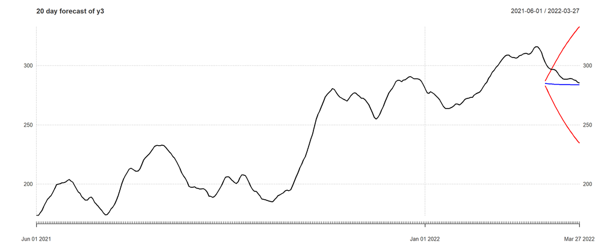

```r
par(mfrow = c(1, 1))

plot(forecasting_y3[, c("y3", "f_mean", "f_lower", "f_upper")],
     major.ticks = "years",
     grid.ticks.on = "years",
     grid.ticks.lty = 3,
     main = "20 day forecast of y3",
     col = c("black", "blue", "red", "red"))
```

## We need to dive deeper

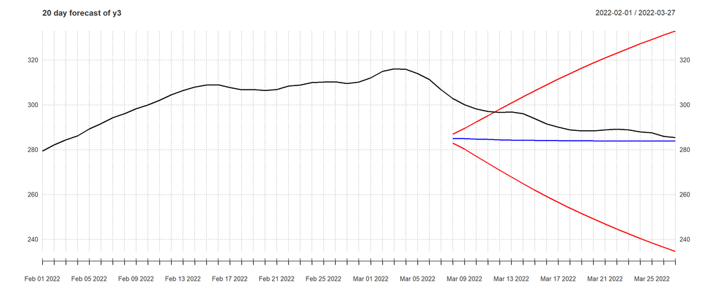

```r
plot(forecasting_y3["2022-02/", # limit the rows
           c("y3", "f_mean", "f_lower", "f_upper")],
     major.ticks = "days",
     grid.ticks.on = "days",
     grid.ticks.lty = 3,
     main = "20 day forecast of y3",
     col = c("black", "blue", "red", "red"))
```

We can see that our blue line(our forecasts) is located between red lines(boundaries). In the first days of comparisons, deviation from original series is high. However, it approachs black line in the end of sample.

## Forecasting for y10

```r
tail(TMS.arimapart, 20)
```

```
               y3    y10   dy3  dy10
2022-03-08 302.89 253.33 -3.87 -1.81
2022-03-09 300.11 251.60 -2.78 -1.73
2022-03-10 298.22 250.84 -1.89 -0.76
2022-03-11 297.11 250.14 -1.11 -0.70
2022-03-12 296.66 249.92 -0.45 -0.22
2022-03-13 296.83 250.31  0.17  0.39
2022-03-14 296.04 249.75 -0.79 -0.56
2022-03-15 293.82 249.04 -2.22 -0.71
2022-03-16 291.49 247.09 -2.33 -1.95
2022-03-17 290.05 246.74 -1.44 -0.35
2022-03-18 288.80 246.23 -1.25 -0.51
2022-03-19 288.38 246.42 -0.42  0.19
2022-03-20 288.44 246.38  0.06 -0.04
2022-03-21 288.86 246.68  0.42  0.30
2022-03-22 289.20 246.30  0.34 -0.38
2022-03-23 288.83 245.85 -0.37 -0.45
2022-03-24 287.98 245.64 -0.85 -0.21
2022-03-25 287.54 245.77 -0.44  0.13
2022-03-26 286.01 244.87 -1.53 -0.90
2022-03-27 285.43 244.08 -0.58 -0.79
```

```r
forecasts <- forecast(y10_arima, # model for prediction
                      h = 20) # how many periods outside the sample
forecasts
```

```
    Point Forecast    Lo 80    Hi 80    Lo 95    Hi 95
301       243.2799 242.3921 244.1677 241.9221 244.6377
302       242.7846 241.0371 244.5320 240.1121 245.4571
303       242.3408 239.5547 245.1268 238.0799 246.6016
304       241.9608 238.1943 245.7272 236.2004 247.7211
305       241.7312 236.9755 246.4868 234.4580 249.0043
306       241.4810 235.7462 247.2159 232.7103 250.2517
307       241.3199 234.6647 247.9752 231.1416 251.4983
308       241.1933 233.6320 248.7546 229.6292 252.7574
309       241.0672 232.6457 249.4886 228.1877 253.9467
310       240.9990 231.7554 250.2426 226.8621 255.1359
311       240.9235 230.8852 250.9617 225.5713 256.2756
312       240.8691 230.0770 251.6612 224.3640 257.3742
313       240.8340 229.3148 252.3532 223.2169 258.4511
314       240.7928 228.5761 253.0094 222.1090 259.4765
315       240.7715 227.8865 253.6565 221.0655 260.4775
316       240.7497 227.2187 254.2808 220.0558 261.4437
317       240.7309 226.5791 254.8828 219.0875 262.3743
318       240.7214 225.9696 255.4732 218.1604 263.2823
319       240.7083 225.3760 256.0406 217.2595 264.1571
320       240.7012 224.8077 256.5946 216.3942 265.0081
```

```r
str(forecasts)
```

```
List of 10
 $ method   : chr "ARIMA(3,1,2)"
 $ model    :List of 18
  ..$ coef     : Named num [1:5] -0.449 0.303 0.536 1.144 0.758
  .. ..- attr(*, "names")= chr [1:5] "ar1" "ar2" "ar3" "ma1" ...
  ..$ sigma2   : num 0.48
  ..$ var.coef : num [1:5, 1:5] 0.01108 -0.00075 -0.00582 -0.00803 -0.00281 ...
  .. ..- attr(*, "dimnames")=List of 2
  .. .. ..$ : chr [1:5] "ar1" "ar2" "ar3" "ma1" ...
  .. .. ..$ : chr [1:5] "ar1" "ar2" "ar3" "ma1" ...
  ..$ mask     : logi [1:5] TRUE TRUE TRUE TRUE TRUE
  ..$ loglik   : num -313
  ..$ aic      : num 637
  ..$ arma     : int [1:7] 3 2 0 0 1 1 0
  ..$ residuals: Time-Series [1:300] from 1 to 300: 0.188 0.012 0.926 0.456 1.237 ...
  ..$ call     : language auto.arima(y = TMS.arimapart$y10, d = 1, max.p = 6, max.q = 6, max.order = 12,      start.p = 1, start.q = 1, ic | __truncated__ ...
  ..$ series   : chr "TMS.arimapart$y10"
  ..$ code     : int 0
  ..$ n.cond   : int 0
  ..$ nobs     : int 299
  ..$ model    :List of 10
  .. ..$ phi  : num [1:3] -0.449 0.303 0.536
  .. ..$ theta: num [1:2] 1.144 0.758
  .. ..$ Delta: num 1
  .. ..$ Z    : num [1:4] 1 0 0 1
  .. ..$ a    : num [1:4] -0.79 -1.155 -0.615 244.87
  .. ..$ P    : num [1:4, 1:4] -1.11e-16 0.00 0.00 4.99e-17 0.00 ...
  .. ..$ T    : num [1:4, 1:4] -0.449 0.303 0.536 1 1 ...
  .. ..$ V    : num [1:4, 1:4] 1 1.144 0.758 0 1.144 ...
  .. ..$ h    : num 0
  .. ..$ Pn   : num [1:4, 1:4] 1.00 1.14 7.58e-01 7.83e-17 1.14 ...
  ..$ bic      : num 659
  ..$ aicc     : num 638
  ..$ x        : Time-Series [1:300] from 1 to 300: 188 188 189 190 193 ...
  ..$ fitted   : Time-Series [1:300] from 1 to 300: 188 188 188 190 191 ...
  ..- attr(*, "class")= chr [1:3] "forecast_ARIMA" "ARIMA" "Arima"
 $ level    : num [1:2] 80 95
 $ mean     : Time-Series [1:20] from 301 to 320: 243 243 242 242 242 ...
 $ lower    : Time-Series [1:20, 1:2] from 301 to 320: 242 241 240 238 237 ...
  ..- attr(*, "dimnames")=List of 2
  .. ..$ : NULL
  .. ..$ : chr [1:2] "80%" "95%"
 $ upper    : Time-Series [1:20, 1:2] from 301 to 320: 244 245 245 246 246 ...
  ..- attr(*, "dimnames")=List of 2
  .. ..$ : NULL
  .. ..$ : chr [1:2] "80%" "95%"
 $ x        : Time-Series [1:300] from 1 to 300: 188 188 189 190 193 ...
 $ series   : chr "TMS.arimapart$y10"
 $ fitted   : Time-Series [1:300] from 1 to 300: 188 188 188 190 191 ...
 $ residuals: Time-Series [1:300] from 1 to 300: 0.188 0.012 0.926 0.456 1.237 ...
 - attr(*, "class")= chr "forecast"
```

```r
forecasts$mean
```

```
Time Series:
Start = 301
End = 320
Frequency = 1
 [1] 243.2799 242.7846 242.3408 241.9608 241.7312 241.4810 241.3199 241.1933
 [9] 241.0672 240.9990 240.9235 240.8691 240.8340 240.7928 240.7715 240.7497
[17] 240.7309 240.7214 240.7083 240.7012
```

```r
class(forecasts$mean)
```

```
[1] "ts"
```

```r
as.numeric(forecasts$mean)
```

```
 [1] 243.2799 242.7846 242.3408 241.9608 241.7312 241.4810 241.3199 241.1933
 [9] 241.0672 240.9990 240.9235 240.8691 240.8340 240.7928 240.7715 240.7497
[17] 240.7309 240.7214 240.7083 240.7012
```

```r
forecasts$lower
```

```
Time Series:
Start = 301
End = 320
Frequency = 1
         80%      95%
301 242.3921 241.9221
302 241.0371 240.1121
303 239.5547 238.0799
304 238.1943 236.2004
305 236.9755 234.4580
306 235.7462 232.7103
307 234.6647 231.1416
308 233.6320 229.6292
309 232.6457 228.1877
310 231.7554 226.8621
311 230.8852 225.5713
312 230.0770 224.3640
313 229.3148 223.2169
314 228.5761 222.1090
315 227.8865 221.0655
316 227.2187 220.0558
317 226.5791 219.0875
318 225.9696 218.1604
319 225.3760 217.2595
320 224.8077 216.3942
```

```r
forecasts$upper
```

```
Time Series:
Start = 301
End = 320
Frequency = 1
         80%      95%
301 244.1677 244.6377
302 244.5320 245.4571
303 245.1268 246.6016
304 245.7272 247.7211
305 246.4868 249.0043
306 247.2159 250.2517
307 247.9752 251.4983
308 248.7546 252.7574
309 249.4886 253.9467
310 250.2426 255.1359
311 250.9617 256.2756
312 251.6612 257.3742
313 252.3532 258.4511
314 253.0094 259.4765
315 253.6565 260.4775
316 254.2808 261.4437
317 254.8828 262.3743
318 255.4732 263.2823
319 256.0406 264.1571
320 256.5946 265.0081
```

```r
forecasts_data <- data.frame(f_mean  = as.numeric(forecasts$mean),
                             f_lower = as.numeric(forecasts$lower[, 2]),
                             f_upper = as.numeric(forecasts$upper[, 2]))
forecasts_data
```

| f_mean | f_lower | f_upper |
| --- | --- | --- |
| 243.2799 | 241.9221 | 244.6377 |
| 242.7846 | 240.1121 | 245.4571 |
| 242.3408 | 238.0799 | 246.6016 |
| 241.9608 | 236.2004 | 247.7211 |
| 241.7312 | 234.4580 | 249.0043 |
| 241.4810 | 232.7103 | 250.2517 |
| 241.3199 | 231.1416 | 251.4983 |
| 241.1933 | 229.6292 | 252.7574 |
| 241.0672 | 228.1877 | 253.9467 |
| 240.9990 | 226.8621 | 255.1359 |
| 240.9235 | 225.5713 | 256.2756 |
| 240.8691 | 224.3640 | 257.3742 |
| 240.8340 | 223.2169 | 258.4511 |
| 240.7928 | 222.1090 | 259.4765 |
| 240.7715 | 221.0655 | 260.4775 |
| 240.7497 | 220.0558 | 261.4437 |
| 240.7309 | 219.0875 | 262.3743 |
| 240.7214 | 218.1604 | 263.2823 |
| 240.7083 | 217.2595 | 264.1571 |
| 240.7012 | 216.3942 | 265.0081 |

```r
forecasts_data_xts_y10 <- TMS.arimapart[281:300, "y10"]
forecasts_xts_2 <- xts(forecasts_data,
                       order.by = index(forecasts_data_xts_y10))
forecasts_xts_2
```

```
             f_mean  f_lower  f_upper
2022-03-08 243.2799 241.9221 244.6377
2022-03-09 242.7846 240.1121 245.4571
2022-03-10 242.3408 238.0799 246.6016
2022-03-11 241.9608 236.2004 247.7211
2022-03-12 241.7312 234.4580 249.0043
2022-03-13 241.4810 232.7103 250.2517
2022-03-14 241.3199 231.1416 251.4983
2022-03-15 241.1933 229.6292 252.7574
2022-03-16 241.0672 228.1877 253.9467
2022-03-17 240.9990 226.8621 255.1359
2022-03-18 240.9235 225.5713 256.2756
2022-03-19 240.8691 224.3640 257.3742
2022-03-20 240.8340 223.2169 258.4511
2022-03-21 240.7928 222.1090 259.4765
2022-03-22 240.7715 221.0655 260.4775
2022-03-23 240.7497 220.0558 261.4437
2022-03-24 240.7309 219.0875 262.3743
2022-03-25 240.7214 218.1604 263.2823
2022-03-26 240.7083 217.2595 264.1571
2022-03-27 240.7012 216.3942 265.0081
```

```r
forecasting_y10 <- merge(financial_data$y10, forecasts_xts_2)
tail(forecasting_y10, n = 20)
```

```
              y10   f_mean  f_lower  f_upper
2022-03-08 253.33 243.2799 241.9221 244.6377
2022-03-09 251.60 242.7846 240.1121 245.4571
2022-03-10 250.84 242.3408 238.0799 246.6016
2022-03-11 250.14 241.9608 236.2004 247.7211
2022-03-12 249.92 241.7312 234.4580 249.0043
2022-03-13 250.31 241.4810 232.7103 250.2517
2022-03-14 249.75 241.3199 231.1416 251.4983
2022-03-15 249.04 241.1933 229.6292 252.7574
2022-03-16 247.09 241.0672 228.1877 253.9467
2022-03-17 246.74 240.9990 226.8621 255.1359
2022-03-18 246.23 240.9235 225.5713 256.2756
2022-03-19 246.42 240.8691 224.3640 257.3742
2022-03-20 246.38 240.8340 223.2169 258.4511
2022-03-21 246.68 240.7928 222.1090 259.4765
2022-03-22 246.30 240.7715 221.0655 260.4775
2022-03-23 245.85 240.7497 220.0558 261.4437
2022-03-24 245.64 240.7309 219.0875 262.3743
2022-03-25 245.77 240.7214 218.1604 263.2823
2022-03-26 244.87 240.7083 217.2595 264.1571
2022-03-27 244.08 240.7012 216.3942 265.0081
```

Here we applied the same procedure as we did for y3.

## Plotting forecast of y10

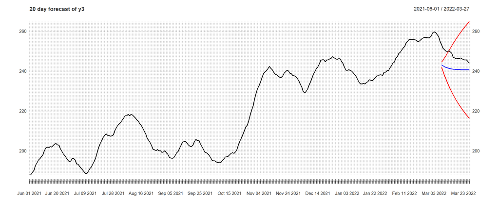

```r
par(mfrow = c(1, 1))

plot(forecasting_y10[, c("y10", "f_mean", "f_lower", "f_upper")],
     major.ticks = "days",
     grid.ticks.on = "days",
     grid.ticks.lty = 3,
     main = "20 day forecast of y3",
     col = c("black", "blue", "red", "red"))
```

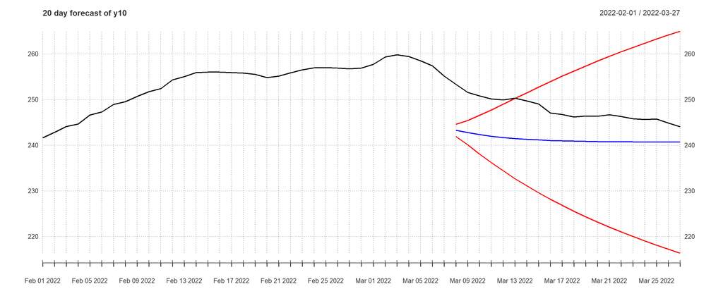

```r
plot(forecasting_y10["2022-02/", # limit the rows
                    c("y10", "f_mean", "f_lower", "f_upper")],
     major.ticks = "days",
     grid.ticks.on = "days",
     grid.ticks.lty = 3,
     main = "20 day forecast of y10",
     col = c("black", "blue", "red", "red"))
```

Here we can visually interprete that previous ARIMA model was better y3, even though in the end of sample forecasting line approachs original line. However, we will make decision after comparing error metrics.

## Error metrics for y3

```r
TSy3 <- forecasting_y3
TSy3$mae <- abs(TSy3$y3 - TSy3$f_mean )
TSy3$mse <- (TSy3$y3 - TSy3$f_mean ) ^ 2
TSy3$mape <- abs((TSy3$y3 - TSy3$f_mean)/TSy3$y3)
TSy3$amape <-  abs((TSy3$y3 - TSy3$f_mean)/(TSy3$y3 + TSy3$f_mean))
tail(TSy3, 20)
```

```
               y3   f_mean  f_lower  f_upper       mae        mse        mape
2022-03-08 302.89 285.0073 283.0169 286.9976 17.882703 319.791074 0.059040256
2022-03-09 300.11 284.9394 280.3470 289.5318 15.170620 230.147709 0.050550198
2022-03-10 298.22 284.7407 277.1153 292.3662 13.479258 181.690390 0.045199040
2022-03-11 297.11 284.5761 273.9515 295.2007 12.533876 157.098036 0.042185977
2022-03-12 296.66 284.4397 270.8429 298.0365 12.220300 149.335727 0.041192947
2022-03-13 296.83 284.3266 267.8055 300.8478 12.503359 156.333989 0.042122963
2022-03-14 296.04 284.2329 264.8529 303.6130 11.807055 139.406552 0.039883310
2022-03-15 293.82 284.1553 261.9937 306.3169  9.664704  93.406507 0.032893282
2022-03-16 291.49 284.0909 259.2320 308.9498  7.399055  54.746008 0.025383562
2022-03-17 290.05 284.0376 256.5688 311.5065  6.012384  36.148759 0.020728784
2022-03-18 288.80 283.9934 254.0024 313.9844  4.806580  23.103207 0.016643281
2022-03-19 288.38 283.9568 251.5301 316.3835  4.423206  19.564752 0.015338117
2022-03-20 288.44 283.9264 249.1480 318.7049  4.513560  20.372221 0.015648175
2022-03-21 288.86 283.9013 246.8518 320.9508  4.958715  24.588851 0.017166498
2022-03-22 289.20 283.8804 244.6368 323.1240  5.319561  28.297734 0.018394058
2022-03-23 288.83 283.8632 242.4985 325.2278  4.966838  24.669479 0.017196406
2022-03-24 287.98 283.8488 240.4323 327.2654  4.131156  17.066446 0.014345286
2022-03-25 287.54 283.8370 238.4336 329.2404  3.703021  13.712364 0.012878281
2022-03-26 286.01 283.8271 236.4983 331.1560  2.182854   4.764853 0.007632091
2022-03-27 285.43 283.8190 234.6223 333.0157  1.611003   2.595332 0.005644128
                 amape
2022-03-08 0.030418074
2022-03-09 0.025930495
2022-03-10 0.023122068
2022-03-11 0.021547489
2022-03-12 0.021029610
2022-03-13 0.021514611
2022-03-14 0.020347416
2022-03-15 0.016721656
2022-03-16 0.012854933
2022-03-17 0.010472938
2022-03-18 0.008391471
2022-03-19 0.007728327
2022-03-20 0.007885787
2022-03-21 0.008657559
2022-03-22 0.009282399
2022-03-23 0.008672773
2022-03-24 0.007224462
2022-03-25 0.006480872
2022-03-26 0.003830663
2022-03-27 0.002830051
```

```r
mean_errors <- colMeans(TSy3[, c("mae", "mse", "mape", "amape")], na.rm = TRUE)
print(mean_errors)
```

```
        mae         mse        mape       amape
 7.96449033 84.84199955  0.02700333  0.01374718
```

## Error metrics for y10

```r
TSy10 <- forecasting_y10
TSy10$mae <- abs(TSy10$y10 - TSy10$f_mean )
TSy10$mse <- (TSy10$y10 - TSy10$f_mean ) ^ 2
TSy10$mape <- abs((TSy10$y10 - TSy10$f_mean)/TSy10$y10)
TSy10$amape <-  abs((TSy10$y10 - TSy10$f_mean)/(TSy10$y10 + TSy10$f_mean))
tail(TSy10, 20)
```

```
              y10   f_mean  f_lower  f_upper       mae       mse       mape
2022-03-08 253.33 243.2799 241.9221 244.6377 10.050080 101.00411 0.03967189
2022-03-09 251.60 242.7846 240.1121 245.4571  8.815409  77.71144 0.03503740
2022-03-10 250.84 242.3408 238.0799 246.6016  8.499246  72.23718 0.03388313
2022-03-11 250.14 241.9608 236.2004 247.7211  8.179237  66.89992 0.03269864
2022-03-12 249.92 241.7312 234.4580 249.0043  8.188822  67.05681 0.03276577
2022-03-13 250.31 241.4810 232.7103 250.2517  8.828979  77.95086 0.03527218
2022-03-14 249.75 241.3199 231.1416 251.4983  8.430059  71.06589 0.03375399
2022-03-15 249.04 241.1933 229.6292 252.7574  7.846698  61.57067 0.03150778
2022-03-16 247.09 241.0672 228.1877 253.9467  6.022838  36.27458 0.02437508
2022-03-17 246.74 240.9990 226.8621 255.1359  5.740982  32.95888 0.02326734
2022-03-18 246.23 240.9235 225.5713 256.2756  5.306546  28.15943 0.02155117
2022-03-19 246.42 240.8691 224.3640 257.3742  5.550929  30.81282 0.02252629
2022-03-20 246.38 240.8340 223.2169 258.4511  5.545964  30.75772 0.02250980
2022-03-21 246.68 240.7928 222.1090 259.4765  5.887248  34.65969 0.02386593
2022-03-22 246.30 240.7715 221.0655 260.4775  5.528499  30.56431 0.02244620
2022-03-23 245.85 240.7497 220.0558 261.4437  5.100262  26.01268 0.02074542
2022-03-24 245.64 240.7309 219.0875 262.3743  4.909076  24.09902 0.01998484
2022-03-25 245.77 240.7214 218.1604 263.2823  5.048623  25.48860 0.02054206
2022-03-26 244.87 240.7083 217.2595 264.1571  4.161712  17.31985 0.01699560
2022-03-27 244.08 240.7012 216.3942 265.0081  3.378820  11.41642 0.01384308
                 amape
2022-03-08 0.020237373
2022-03-09 0.017831076
2022-03-10 0.017233530
2022-03-11 0.016621062
2022-03-12 0.016655756
2022-03-13 0.017952704
2022-03-14 0.017166717
2022-03-15 0.016006049
2022-03-16 0.012337908
2022-03-17 0.011770603
2022-03-18 0.010892965
2022-03-19 0.011391451
2022-03-20 0.011383014
2022-03-21 0.012077081
2022-03-22 0.011350489
2022-03-23 0.010481433
2022-03-24 0.010093275
2022-03-25 0.010377621
2022-03-26 0.008570630
2022-03-27 0.006969783
```

```r
mean_errors <- colMeans(TSy10[, c("mae", "mse", "mape", "amape")], na.rm = TRUE)
print(mean_errors)
```

```
        mae         mse        mape       amape
 6.55100154 46.20104376  0.02636218  0.01337003
```